# Algoritmos de aumento por camino para máximo flujo

Miguel Miní

17/7/2020

## Preliminares para el teorema del máximo flujo - mínino corte

En la última clase nosotros afirmamos que si no existe un camino desde s hacia t (con capacidad residual positiva en toda arista) en el grafo residual $G_f$, entonces f es un flujo máximo en G. veremos como esto deriva en el famoso teorema del máximo flujo/mínimo corte

### (s, t) - Cortes

necesitamo antes una importante definición, un corte será el dual de un flujo en un sentido que se explicará luego.

#### Definición (s, t) - corte.

Un $(s, t)$ - corte de un grafo $G = (V, E)$ es una partición de $V$ en conjuntos $A$, $B$ con $s \in A$ y $t \in B$. a veces simplemente podemos decir “corte”.

En la figura 1 podemos ver una manera de pensar un corte de un grafo. Tal que las aristas se separan en 4 categorias: aquellas con ambos vertices finales en A, aquellas con ambos vértices finales en B, aquellos que comienzan en A y finalizan en B, y aquellos que comienzan en B y finalizan en A.

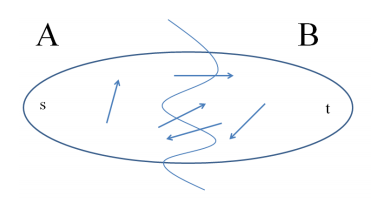

La capacidad de un (s, t) - corte (A, B) es definido como:

$$\sum_{e \in \delta^+(A)} u_e$$

donde $\delta^+ (A)$ denota las aristas saliendo de A. Diremos que un corte es mínimo si tiene la menor capacidad posible.

### Condición de optimalidad para el problema del máximo flujo.

Probaremos los siguiente resultados básicos.

#### Teorema 1. (condicion de optimalidad para el flujo máximo)

Sea $f$ es un flujo en un grafo $G$. Los siguientes son equivalentes:

1. $f$ es un flujo máximo de G.
2. Existe un $(s, t)$-corte $(A, B)$ tal que el valor de $f$ es es igual a la capacidad de $(A, B)$
3. No existe un camino $s-t$ (con capacidad residual positiva) en la red residual $G_f$.

el teorema 1 nos dice que cualquiera de los 3 enunciados implica los otros dos. El caso especial que (3) implica (1) nos habla de la afirmación hecha en la anterior clase.

#### Corolario 1.

Si $f$ es un flujo en $G$ tal que la red residual $G_f$ no tiene caminos s-t, entonces f es un flujo máximo.

Note que este último corolario implica la correctitud del algoritmo de Ford-Fulkerson.

#### Prueba del teorema 1:

Probaremos una implicación cíclica: (2) implica (1), (1) implica (3) y (3) implica (2). de esto se sigue que cualquiera de los enunciados implican los otros dos.

##### Paso 1. (2) implica (1):

Nosotros afirmamos, que para todo flujo $f$ y todo $(s, t)$-corte $(A, B)$.

$$\text{valor de f } \le \text{capacidad de } (A, B)$$
Esta afirmación implica que todo valor de un flujo es a lo más algún valor de un corte; ver figura 2.

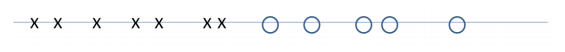

Para ver porque la afirmacion nos dice la deseada implicación, supongamos que (2) cumple, esto corresponde para un “x” y un “o” en la misma posición. Por la afirmación, no “x”s pueden aparecer a la derecha de este punto de encuentro. Nosotros probaremos una resumida prueba algebraica.

Fijemos $f$ y $(A, B)$. Por definición,

$$\text{valor de f } = \sum_{e \in \delta^+(s)} f_e = \sum_{e \in \delta^+(s)} f_e - \sum_{e \in \delta^-(s)} f_e ~\dots (1)$$

La segunda ecuación es puesta por conveniencia, y sigue desde nuestra primera asunción que s no tiene vertices de entrada. Además, tengamos en cuenta que la restricción de conservación nos dice:

$$\sum_{e \in \delta^+(v)} f_e - \sum_{e \in \delta^-(v)} f_e = 0 ~\dots (2)$$

Para todo $v \neq s, t$. Agregando la ecuación (2) correspondiente para todo vertice de $A \setminus \{s\}$ para la ecuación (1) nos da:

$$\text{valor de f } = \sum_{v \in A} (\sum_{e \in \delta^+(v)} f_e - \sum_{e \in \delta^-(v)} f_e) ~\dots (3)$$

Lo siguiente que queremos pensar es sobre la expresión en (3) desde un punto de vista centrado en las aristas, en vez de centrado en los nodos. Como contribuye una arista para (3)? La respuesta depende sobre cual de los 4 tipos la arista es. Si ambos de los puntos finales de $e$ están en B, entonces $e$ no aporta a la suma (3). si $e$ tiene ambos puntos en $A$, entonces contribuye con $f_e$ una vez y con $-f_e$ una vez. Así las aristas en $A$ contribuyen con $0$. Similarmente las aristas saliendo de $A$ aportan con $f_e$ y las aristas entrando a $A$ aportan con $-f_e$. En resumen:

$$\text{valor de f} = \sum_{e \in \delta^+(A)} f_e - \sum_{e \in \delta^-(A)} f_e$$

Esta ecuación nos dice que el flujo neto (flujo a favor menor flujo en contra) a traves de todo corte es exactamente el mismo, llamado el valor del flujo f. Finalmente, usando la restricción de capacidad y el hecho que todo valor de flujo es no-negativo tenemos:

$$\text{valor de f} = \sum_{e \in \delta^+(A)} f_e (\le u_e) - \sum_{e \in \delta^-(A)} f_e (\ge 0)$$
$$\le \sum_{e \in \delta^+(A)} u_e ~\dots (4)$$
$$\text{capacidad de } (A, b) ~\dots(5)$$

Lo cual completa la prueba de la primera implicación.

##### Paso 2. (1) implica (3):

Este paso es fácil. Nosotros probamos la opuesto. Sea $f$ un flujo tal que $G_f$ tiene un camino $s-t$ $P$ con capacidad residual positiva. Como en el algoritmo de Ford-Fulkerson, nosotros aumentamos a traves de P para produir un nuevo flujo $f^{'}$ con valor estrictamente mayor. Esto nos dice que f no es un máximo flujo.

##### Paso 3. (3) implica (2):

El truco de este paso está en definir

$$A = \{v \in V : \text{ existe un camino s} \sim \text{v en } G_f\}$$

Conceptualmente, si nosotros ejecutamos nuestra sub-rutina favorita (ejm. BFS o DFS) desde s mientra se detenga; A es el conjunto de vertices que logras alcanzar. (Esto solo lo ejecutamos en nuestra mente, por el proposito de la prueva) Notar que $(A, V-A)$ es un $(s, t)$-corte. Ciertamente $s \in A$, comor $s$ puede alcanzarse a si mismo en $G_f$. Por asunción, $G_f$ no tiene un camino $s-t$, tal que $t \notin A$. Así el corte debería lucir como en la figura 3, que no tiene aristas (con capacidad residual possitiva) saliendo de A. La razón es que si existiera dichas aristas, entonces nuestra busqueda en el grafo no puedo haber terminado y A debería ser un conjunto de mayor tamaño.

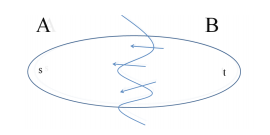

Si traducimos la figura 3 en la imagen, cual concierne la red residual $G_f$, regresando al flujo f en la red original $G$.

1. Toda arista saliendo de $A$ en $G$ (sea $\delta^+(A)$) es saturada (que es $f_e = u_e$). En caso que $f_e < u_e$ para $e \in \delta^+(A)$, entonces la red residual $G_f$ debería contener una arista en el mismo sentido que e (con capacidad residual positiva) que sería una arista saliendo de A en $G_f$ que contradice la Figura 3.
2. Toda arista entrando en $A$ en $G$ (sea $\delta^-(A)$) debe ser 0 ($f_e = 0$). En caso de que $f_e > 0$ para $e \in \delta^-(A)$, entonces la red residual $G_f$ debería contener una arista en reversa de tal forma que saldría de $A$ en $G_f$ que contradice la Figura 3.

Estos dos puntos implican que la inecuación (4) cumple con iguadad, cuando

$$\text{valor de } f = \text{capacidad de } (A, V - A)$$

Esto completa la prueba.

Nosotros podemos derivar el siguiente corolario.

#### Corolario 2. (Teorema del máximo flujo / mínimo corte) En toda red.

$$\text{máximo valor de un flujo} = \text{minima capacidad de un (s, t)-corte}$$

#### *Prueba*: La primera parte de la prueba del teorema 1 implica que el valor máximo de un flujo

no puede exceder la mínima capacidad de un $(s, t)$-corte. La tercera parte de la prubeaimplica que no puede existir un gap entre el valor del flujo maximo y la mínima capacidad de un corte.

Seguimos en una consecuencia algoritmica: El problema del mínimo corte reduce para el problema del máximo flujo.

#### Corolario 3. Dado un máximo flujo, el mínimo corte puede ser computado en tiempo lineal.

#### *prueba*:

Usamos BFS o DFS para computar, en tiempo lineal, el conjunto $A$ deste la tercera parte del teorema 1. La prueba nos muestra que $(A, V - A)$ es el corte mínimo.

### 3. El algoritmo Edmonds-karp: Aumentos por camino mínimo.

#### El algoritmo:

Con un entendimiento sólido de cuando y porqué el algoritmo de flujo máximo es correcto, nosotros ahora nos enfocamos sobre la optimización del tiempo de ejecución. Nuestro problema con el algoritmo de ford-fulkerson es la elección arbitraria de un camino $s-t$. Esto motiva la elección de un camino de una forma más inteligente. El algoritmo de Edmonds-karp es el mismo que el algoritmo Ford-Fulkerson, excepto que este siempre escoge el manor camino a aumentar en la red residual. note que nosotros podemos usar un BFS para este fin.

```cpp
#include <bits/stdc++.h>
#define all(x) x.begin(), x.end()
#define sz(x) (int)x.size()
#define trav(i, x) for (auto i : x)
#define re(x, y, z) for (int x=y; x<z; ++x)
#define eb emplace_back
#define set_to(x, v) fill(all(x), v)
using namespace std;
using ll = long long;
using vi = vector<int>;
const int inf = 1e9;
struct EdmondKarp {
    struct Edge {
        int to, cap, flow, link;
        Edge() {}
        Edge(int to, int cap, int link, int flow=0):
            to(to), cap(cap), link(link), flow(flow) {}
    };
    vector<vector<Edge>> g;
    vi d;

    EdmondKarp(int n): g(n), d(n), pi(n) {}

    void addEdge(int a, int b, int cap) {
        if (a == b) return;
      int pa = sz(g[a]), pb = sz(g[b]);
        g[a].eb(b, cap, pb); g[b].eb(a, 0, pa);
    }

    bool bfs(int src, int snk) {
        queue<int> q({src});
        set_to(d, inf);
        d[src] = 0;
        pi[src] = -1;
        while (!q.empty()) {
            int v = q.front(); q.pop();
            if (v == snk) return true;
            trav(e, g[v]) {
                if (e.flow >= e.cap) continue;
                if (d[e.to] > d[v] + 1) {
                  pi[e.to] = e.link;
                    d[e.to] = d[v] + 1;
                    q.emplace(e.to);
                }
            }
        }
        return false;
    }

    ll solve(int s, int t) {
        ll res = 0;
        while (bfs(s, t)) {
            int v = t;
            int flow = inf;
            while (v != s) {
              auto e = g[g[v][pi[v]].to][g[v][pi[v]].link];
              flow = min(flow, e.cap - e.flow);
            }
            res += flow;
            v = t;
            while (v != s) {
              auto& e = g[g[v][pi[v]].to][g[v][pi[v]].link];
              e.flow += flow;
              g[v][pi[v]].flow -= flow;
            }
        }
        return res;
    }
};
```

#### Análisis:

Como una especialización del algoritmo de Ford-Fulkerson, El algoritmo de Edmonds-Karp mantiene la misma correctitud, qué hacerca del tiempo de ejecucion?

##### Teorema 2. (Tiempo de ejecución de Edmonds-karp)

El algoritmo de Edmonds-Karp se ejecuta en $O(m^2n)$

##### Lema 1. (Lema del progreso EK)

Fijada una red $G$. Para un flujo $f$, sea $d(f)$ el numero mínimo de aristas en un camino $s-t$ en $G_f$, o $+\infty$ si no existe dicho camino.

1. $d(f)$ nunca decrece durante la ejecución del algoritmo de Edmonds-Karp.
2. $d(f)$ incrementa al menos uno por m iteraciones.

Como $d(f) \in \{0, 1, 2, \dots, n-2, n-1, +\infty\}$, una vez que $d(f) \ge n$ nosotros conocemos que $d(f) = +\infty$ y s y t se desconectan en $G_f$. Así el lema 1 implica que el algoritmo de Edmonds-Karp termina despues de $m n$ iteraciones. Como en cada iteración ejecutamos un BFS, nuestro tiempo de ejecución es $O(m^2n)$ como nos dice el teorema 2.

Para el analisis, imaginamos que ejecutamos un BFS en $G_f$ iniciando desde la fuente s. Recordamos que BFS discubre los vertices en “niveles”, con $s$ en el nivel 0, y el nivel $i+1$ consiste de los vertices que no estan en los anteriores niveles y que son alcanzables por una arista desde el nivel i. Si denotamos las arista de $G_f$ que van hacia un nivel mayor como *forward*, las que van al mismo nivel *sideways* y *backward* como las aristas que van hacia atras. Por la definición de BFS, no pueden existir aristas *backward* o *sideways* que mejoren un camino corto.

Definimos $L_f$ (*layered subgraph*), como el subgrafo de $G_f$ consistiendo solo de las aristas *forward* (figura 4). (vertices en los niveles despues del que contiene a t son irrelevantes y pueden ser descartados).

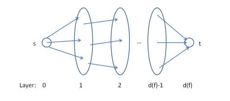

Porque la molestia de definir $L_f$? Porque esta es una forma sucinta de codificar todos los caminos mínimos $s-t$ de $G_f$ - los caminos por el cual el algoritmo de Edmonds-Karp puede aumentar. Formalmente, todo camino $s-t$ en $L_f$ comprende de solo aristas *forward* del BFS y por tanto tiene exactamente $d(f)$ saltos de niveles, el mínimo posible. En contraposición, cualquier camino que este en $G_f$ pero no en $L_f$ deberia contener al menos una arista $sideways$ o $backward$ y por tanto debe tener al menos una distancia de $d(f) + 1$.

##### Prueba del lema 1.

Iniciamos con la parte (a) del lema. Notamos que la única cosa que nos puede preocupar es que aumentar por un camino mínimo produzca un nuevo, camino mínimo que sea mejor que cualquiera en $L_f$. Supongamos que el algoritmo de Edmonds-Karp aumenta el flujo actual f por el mínimo camino $P$. Este es claramente un camino en el grafo $L_f$. Las posiblemente nuevas aristas creadas al realizar esto son las aristas con dirección invertida en $P$. Note que estas solo son aristas *backward*, tal que cualquier camino $s-t$ de $G_f$ que usa tales aristas tiene al menos $d(f) + 2$ aristas. Así no pueden existir nuevos mejores caminos mínimo creados al hacer este aumento. Ahora consideramos una ejecución de $k$ iteraciones del algoritmo de Edmonds-Karp en el cual el valor de $d(f) = c$ se mantiene constante. debemos ver que $k \le m$. Antes de la primera de estas iteraciones, nosotros guardamos una copia de la actual red por niveles: Sea $F$ que denota las aristas de $L_f$ en este tiempo, y $v_0 = {s}, v_1, v_2, \dots, v_c$ los vertices en los varios niveles. Consideramos las primeras k iteraciones. Como en la prueba de la parte (a), las unicas nuevas aristas introducidas vas desde $v_i$ hacia $v_{i-1}$. Por asunción, despues del aumento, solo las aristas de F cambian y no vuelven a regresar al menos para este layered graph, además como la arista de mínim capacidad siempre se invierte, no podemos invertir más de m aristas lo cual termina con la prueba.

### Algoritmo de Dinitz: Flujo en bloque.

El siguiente algoritmo osa una fuerte semejanza con el algoritmo de Edmonds-Karp, aunque fue desarrollado independientemente y contemporaneamente por Dinitz. A diferencia del algoritmo de Edmonds-Karp, el algoritmo de Dinitz goza de una modularidad que se presta a algoritmos con mejor tiempo de ejecución.

```cpp
#include <bits/stdc++.h>
#define all(x) x.begin(), x.end()
#define sz(x) (int)x.size()
#define trav(i, x) for (auto i : x)
#define re(x, y, z) for (int x=y; x<z; ++x)
#define eb emplace_back
#define set_to(x, v) fill(all(x), v)
using namespace std;
using ll = long long;
using vi = vector<int>;
const int inf = 1e9;
struct Dinic {
    struct Edge {
        int to, cap, flow, link;
        Edge() {}
        Edge(int to, int cap, int link, int flow=0):
            to(to), cap(cap), link(link), flow(flow) {}
    };
    vector<vector<Edge>> g;
    vi d, pt;

    Dinic(int n): g(n), d(n), pt(n) {}

    void addEdge(int a, int b, int cap) {
        if (a == b) return;
        int pa = sz(g[a]), pb = sz(g[b]);
        g[a].eb(b, cap, pb); g[b].eb(a, 0, pa);
    }

    bool bfs(int src, int snk) {
        queue<int> q({src});
        set_to(d, inf);
        d[src] = 0;
        while (!q.empty()) {
            int v = q.front(); q.pop();
            if (v == snk) return true;
            trav(e, g[v]) {
                if (e.flow >= e.cap) continue;
                if (d[e.to] > d[v] + 1) {
                    d[e.to] = d[v] + 1;
                    q.emplace(e.to);
                }
            }
        }
        return false;
    }

    int dfs(int x, int snk, int flow=inf) {
        if (x == snk || !flow) return flow;
        for (; pt[x] < sz(g[x]); ++pt[x]) {
            auto& e = g[x][pt[x]];
            if (d[e.to] == d[x] + 1) {
                int res = min(e.cap - e.flow, flow);
                if (int push = dfs(e.to, snk, res)) {
                    e.flow += push;
                    g[e.to][e.link].flow -= push;
                    return push;
                }
            }
        }
        return 0;
    }

    ll solve(int s, int t) {
        ll res = 0;
        while (bfs(s, t)) {
            set_to(pt, 0);
            while (int flow = dfs(s, t)) {
                res += flow;
            }
        }
        return res;
    }
};
```

El algoritmo de Dinitz solo puede terminar con una red residual sin caminos $s-t$, que es, con un flujo máximo como ya hemos probado. Mientras que en el algoritmo de Edmonds-Karp nosotros solo formamos el *Layered subgraph* $L_f$ en el analisis, al algoritmo de Dinitz explicitamente construye su red en cada iteracion. Un flujo en bloque es, intuitivamente, un manojo de caminos cortos de aumento que son procesados en *batch*. más formalmente, los flujos en bloque son precisamente lo que sería la posible salida del enfoque greedy ingenuo discutido en la anterior clase. Completamos formalmente:

### Definición (flujo en bloque)

Un flujo en bloque $g$ en una red $G$ es factible flujo tal que, para todo camino $(s, t)$ $P$ de $G$ alguna arista $e$ es saturada por $g$. Que es, un flujo de bloque pone a cero una arista de todo camino $(s, t)$

### Lema 2 (Lema del progreso de Dinitz)

Fijada una red $G$. para un flujo $f$, sea $d(f)$ el numero de aristas en un camino mínimo $(s-t)$ (con capacidad residual positiva) en $G_f$ o $+\infty$ si no existe dicho camino. Si $h$ es obtenido desde $f$ por aumentar $f$ por un flujo en bloque g in $G_f$, entonces $d(h) > d(f)$. Que es, toda iteración del algoritmo de Dinitz incrementa estrictamente la distancia desde $s$ hacia $t$ en el actual grafo residual.

Como $d(f)$ solo puede ir hasta $n-1$ antes de hacerse infinito, Lema 2 inmediatamente implica que el algoritmo de Dinitz termina despues de a lo mas n iteraciones. En este sentido, el problema del flujo máximo reduce para $n$ instancias del prboblema del flujo en bloque en el *layered graph*. El algoritmo de Dinitz por tanto tiene un tiempo de ejecución igual a $O(n x BF)$, donde $BF$ se entiende como el tiempo requerido para computar el flujo en bloque en el *layered graph*.

Se puede probar, pero no se va a enfatizar eso en esta clase, que el tiempo de ejecución de $BF$ es $O(nm)$ que nos da una complejidad de $O(n^2m)$, mejorando la complejidad que nos da Edmonds-Karp.